# Bulk RNA-seq Quantification Report

September 05, 2025

## 1. Alignment statistics

**Alignment statistics** is useful to tell:  
**1）If you have sequenced enough reads?** Usually, **>25M mapped** reads and **>10M uniquely-mapped** reads are expected;  
**2）If your reads have been over-trimmed?** Usually, **>90% Percentage of Filtered Reads** is expected. Over-trimming could happen when the insert size is too small or you picked the wrong Phred score encoding method;  
**3）If your samples are contaminated?** Usually, **>75% Percentage of Mapped Reads** is expected. The most common reason for low mapping rate is the contamination of either DNA or rRNA.

| Sample Name | Number of Total Reads | Number of Filtered Reads | Percentage of Filtered Reads | Number of Mapped Reads | Percentage of Mapped Reads | Number of Uniquely-mapped Reads | Percentage of Uniquely-mapped Reads |
| --- | --- | --- | --- | --- | --- | --- | --- |
| sample1 | 19410373 | 19163544 | 98.73% | 15836491 | 82.64% | 14663015 | 92.59% |

* Percentage of Uniquely-mapped Reads = Number of Uniquely-mapped Reads / Number of Mapped Reads  
* Percentage of Mapped Reads = Number of Mapped Reads / Number of Filtered Reads  
* For paired-end libraries, the numbers in the tables count read pairs.

## 2. Quantification statistics

**Quantification statistics** is used to tell how accurate the quantification results are. Specifically:  
**1）How many transcripts/genes were identified confidently?** Usually, **>65K transcripts** and/or **>15K genes** are expected;  
**2）How accurate the quantification is?** Usually, **>0.85 correlation coefficient** is expected.

| Levels | Identified by RSEM | Identified by Salmon | Identified by Both | Coef_Pearson | Pval_Pearson | rho_Spearman | Pval_Spearman |
| --- | --- | --- | --- | --- | --- | --- | --- |
| Transcript | 91688 | 87038 | 79984 | 0.9790 | 0 | 0.9699 | 0 |
| Gene | 22114 | 22429 | 21363 | 0.9798 | 0 | 0.9877 | 0 |

* Only co-identified transcripts/genes were used in correlation analysis.

## 3. Biotype distribution

**Biotype distribution** provides the composition of types of identified transcripts and genes. Since different bioytpes of transcripts/genes vary hugely in length, GC-content and other properties, **Biotype distribution** could serve as a measure of quantification quality. Empirically,  
**1)** For total RNA libraries, the **protein_coding** transcripts and genes should account for **>40%** and > **50%**, respectively;  
**2)** For mRNA libraries, the **protein_coding** transcripts and genes should accounts for **>80**. For more details about the biotypes: https://www.gencodegenes.org/pages/biotypes.html.

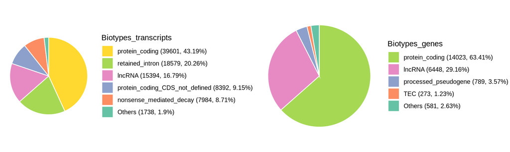

## 4. Quantification accuracy

**Quantification accuracy** is evaluated by the correlation of quantification results by RSEM and Salmon. **>0.85** coefficient for either **Pearson correlation** or **Spearman’s rank correlation** is expected.

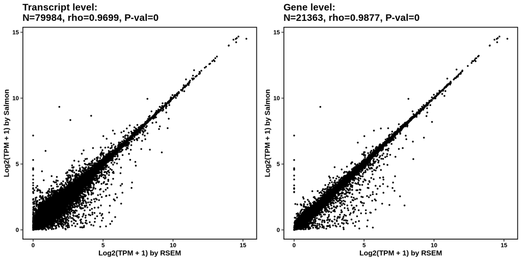

## 5. Genebody coverage statistics

**Genebody coverage statistics** calculates the RNA-Seq reads overage over gene body.  
**1) Mean of Coverage** is the average coverage of all 100 bins of gene body. Usually, **>0.7** is expected.  
**2) Coefficient of Skewness** is a measure of the asymmetry of the distribution of gene body coverage. **Fisher’s moment coefficient of skewness** was calculated by default. The closer to 0, the more symmetric. For more details: https://en.wikipedia.org/wiki/Skewness.

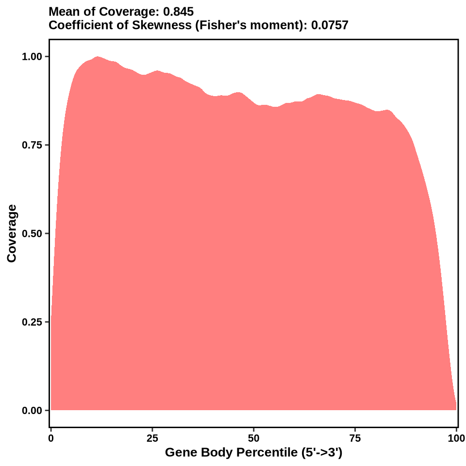